# Experimental Design

#### ANOVA on Two-Way Layout Design (s19)

- for two-way layout design, I’ll skip the manual calculation part. try manual calculation using R by yourself.

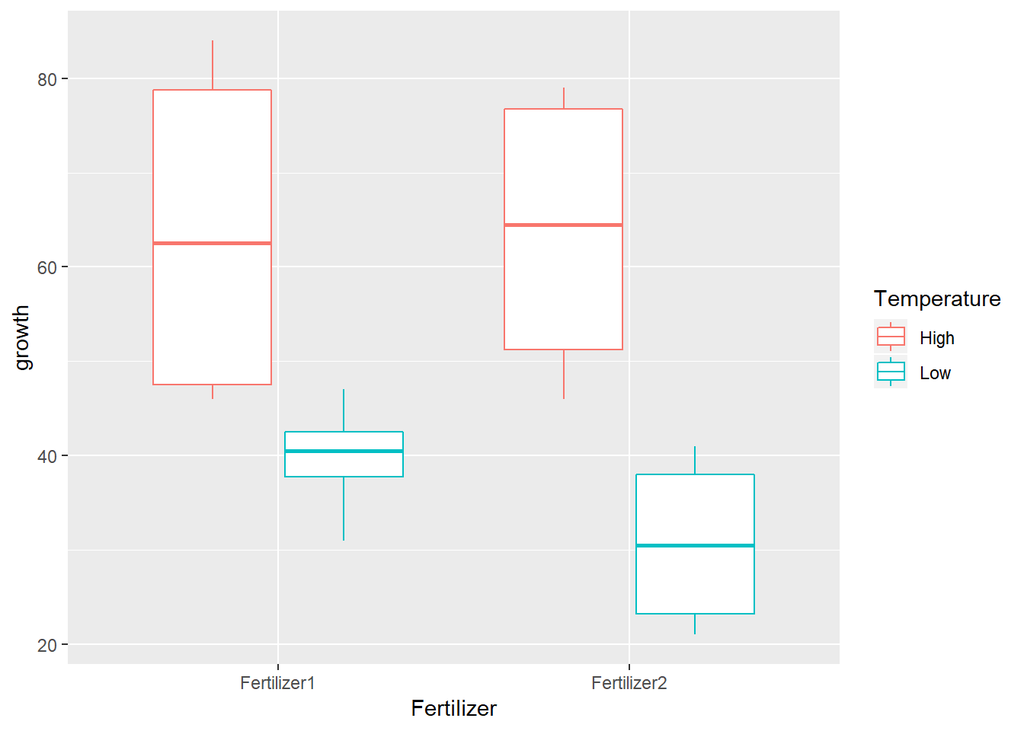

```r
data <- matrix(c(40,24,31,21, 47,37,41,41, 46,53,48,46, 84,76,77,79), nrow = 8, byrow = TRUE)
data <- data.frame(Temperature = c(rep("Low",4), rep("High", 4)),
                   Fertilizer1 = data[,1], Fertilizer2 = data[,2])

growthdf <- data %>% gather(Fertilizer, growth, -Temperature, factor_key = TRUE)

# visualize data
library(ggplot2)
ggplot(growthdf, aes(x = Fertilizer, y = growth, col = Temperature)) +
  geom_boxplot()
```

```r
# base R package
fit <- aov(growth ~ Fertilizer * Temperature, data = growthdf)
summary(fit)
```

```
##                        Df Sum Sq Mean Sq F value  Pr(>F)
## Fertilizer              1     86      86   0.432 0.52346
## Temperature             1   3221    3221  16.257 0.00166 **
## Fertilizer:Temperature  1     77      77   0.386 0.54579
## Residuals              12   2377     198
## ---
## Signif. codes:  0 '***' 0.001 '**' 0.01 '*' 0.05 '.' 0.1 ' ' 1
```

```r
drop1(fit,~.,test = "F") # type III SS and F Tests
```

```
## Single term deletions
##
## Model:
## growth ~ Fertilizer * Temperature
##                        Df Sum of Sq    RSS    AIC F value  Pr(>F)
## <none>                              2377.2 88.018
## Fertilizer              1      0.12 2377.4 86.019  0.0006 0.98037
## Temperature             1   1152.00 3529.3 92.340  5.8151 0.03283 *
## Fertilizer:Temperature  1     76.56 2453.8 86.525  0.3865 0.54579
## ---
## Signif. codes:  0 '***' 0.001 '**' 0.01 '*' 0.05 '.' 0.1 ' ' 1
```

#### Confidence interval in Two-Way layout (s20)

for confidence interval, we use TukeyHSD function again.

$H_{0} = \mu_{11} = ... = \mu_{j, k}$

$H_{A} = \mu_{11} \neq ... \neq \mu_{j, k}$

```r
data <- matrix(c(40,24,31,21, 47,37,41,41, 46,53,48,46, 84,76,77,79), nrow = 8, byrow = TRUE)
data <- data.frame(Temperature = c(rep("Low",4), rep("High", 4)),
                   Fertilizer1 = data[,1], Fertilizer2 = data[,2])

growthdf <- data %>% gather(Fertilizer, growth, -Temperature, factor_key = TRUE)

fit <- aov(growth ~ Fertilizer * Temperature, data = growthdf)
TukeyHSD(fit, conf.level = 0.99) # where fit comes from aov()
```

```
##   Tukey multiple comparisons of means
##     99% family-wise confidence level
##
## Fit: aov(formula = growth ~ Fertilizer * Temperature, data = growthdf)
##
## $Fertilizer
##                           diff       lwr      upr     p adj
## Fertilizer2-Fertilizer1 -4.625 -26.12124 16.87124 0.5234602
##
## $Temperature
##             diff       lwr       upr     p adj
## Low-High -28.375 -49.87124 -6.878757 0.0016633
##
## $`Fertilizer:Temperature`
##                                     diff       lwr       upr     p adj
## Fertilizer2:High-Fertilizer1:High  -0.25 -38.96755 38.467553 0.9999940
## Fertilizer1:Low-Fertilizer1:High  -24.00 -62.71755 14.717553 0.1276054
## Fertilizer2:Low-Fertilizer1:High  -33.00 -71.71755  5.717553 0.0273384
## Fertilizer1:Low-Fertilizer2:High  -23.75 -62.46755 14.967553 0.1328877
## Fertilizer2:Low-Fertilizer2:High  -32.75 -71.46755  5.967553 0.0285670
## Fertilizer2:Low-Fertilizer1:Low    -9.00 -47.71755 29.717553 0.8029139
```

#### Statistical Model for Randomized Block Design (s24)

- Consider table below

| Patient | Low | Medium | High |
| --- | --- | --- | --- |
| 1 | 12.2 | 16.5 | 25.4 |
| 2 | 29.3 | 34.7 | 29.4 |
| 3 | 14.1 | 26.1 | 34.0 |
| 4 | 18.5 | 33.3 | 21.7 |
| 5 | 32.9 | 36.9 | 43.0 |
| 6 | 15.3 | 32.6 | 32.1 |
| 7 | 26.1 | 28.9 | 40.9 |
| 8 | 22.8 | 28.6 | 31.1 |

- Calculate test statistics

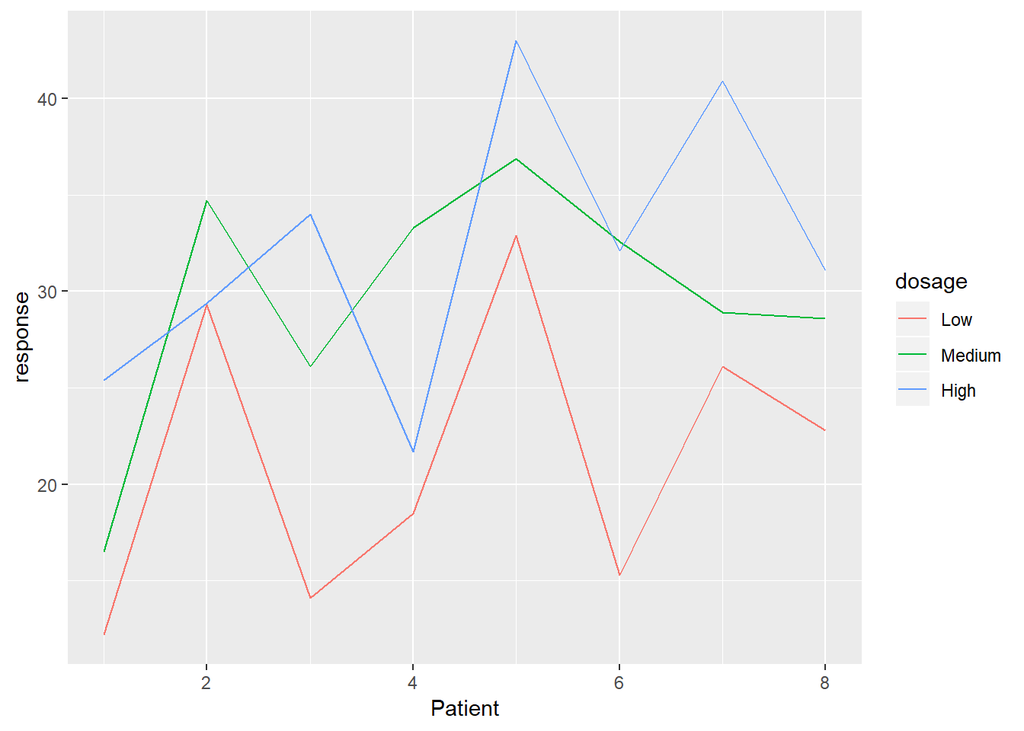

```r
ddl <- matrix(c(1:8,
                12.2, 29.3, 14.1, 18.5, 32.9, 15.3, 26.1, 22.8,
                16.5, 34.7, 26.1, 33.3, 36.9, 32.6, 28.9, 28.6,
                25.4, 29.4, 34.0, 21.7, 43.0, 32.1, 40.9, 31.1), nrow = 8, byrow = FALSE)
rownames(ddl) <- 1:8
colnames(ddl) <- c("Patient", "Low", "Medium", "High")

# tidy data & visualize
ddl_tidy_df <- as.data.frame(ddl) %>% gather(dosage, response, -Patient, factor_key = TRUE)

ggplot(ddl_tidy_df, aes(x = Patient, y = response, col = dosage)) +
  geom_line()
```

```r
ddl_tidy_df$Patient <- as.factor(ddl_tidy_df$Patient)

#### Anova
fit <- aov(response ~ dosage + Patient, data = ddl_tidy_df)
summary(fit)
```

```
##             Df Sum Sq Mean Sq F value  Pr(>F)
## dosage       2  511.4  255.71  10.983 0.00135 **
## Patient      7  724.7  103.53   4.446 0.00852 **
## Residuals   14  326.0   23.28
## ---
## Signif. codes:  0 '***' 0.001 '**' 0.01 '*' 0.05 '.' 0.1 ' ' 1
```

#### Estimation of confidence interval in Randomized Block Design (s26)

```r
ddl <- matrix(c(1:8,
                12.2, 29.3, 14.1, 18.5, 32.9, 15.3, 26.1, 22.8,
                16.5, 34.7, 26.1, 33.3, 36.9, 32.6, 28.9, 28.6,
                25.4, 29.4, 34.0, 21.7, 43.0, 32.1, 40.9, 31.1), nrow = 8, byrow = FALSE)
rownames(ddl) <- 1:8
colnames(ddl) <- c("Patient", "Low", "Medium", "High")

# tidy data & visualize
ddl_tidy_df <- as.data.frame(ddl) %>% gather(dosage, response, -Patient, factor_key = TRUE)

fit <- aov(response ~ dosage + Patient, data = ddl_tidy_df)

# parameter setting for calculation of qvalue
a <- 0.05
k <- 3
df <- 2 * (length(unique(ddl_tidy_df$Patient)) - 1)

# qvalue
q <- qtukey(1 - a, k, df)

TukeyHSD(fit, conf.level = 0.95) # where fit comes from aov()
```

```
##   Tukey multiple comparisons of means
##     95% family-wise confidence level
##
## Fit: aov(formula = response ~ dosage + Patient, data = ddl_tidy_df)
##
## $dosage
##             diff        lwr      upr     p adj
## Medium-Low   8.3 -0.2240681 16.82407 0.0571859
## High-Low    10.8  2.2759319 19.32407 0.0118146
## High-Medium  2.5 -6.0240681 11.02407 0.7418027
```

### Extra Issues

Not included in this tutorial

#### Friedman Test

See Hayter’s book p729 - p731

#### Expansion to Three Factor Design

See Hayter’s book p679 - p687

#### Factorial Design

See Hayter’s book p687 - p693

#### Experimental Design related R packages

for more information about this topic, plz refer to this link https://cran.r-project.org/web/views/ExperimentalDesign.html